# Chatbot&Recommander_system_project : music recommander

A project made by:

- Grégoire CAURIER
- Aref BITAR
- Hamza BENYEMNA

In this project, we will build a song recommender based on our **Spotify** **listening history** and **song features** dataset. We obtained it by doing a demand to Spotify in our account confidential settings. It took 15 days to have it.

## I) Data import

```python
import pandas as pd
import numpy as np
import seaborn as sns
import matplotlib.pyplot as plt
from imblearn.over_sampling import SMOTE
```

### Streaming dataset

```python
streaming = pd.read_csv("StreamingHistory.csv")
streaming.head()
```

|  | Unnamed: 0 | artistName | endTime | msPlayed | trackName |
| --- | --- | --- | --- | --- | --- |
| 0 | 0 | Roy Woods | 2018-12-18 21:44 | 77725 | Down Girl |
| 1 | 1 | Drake | 2018-12-19 01:27 | 1000 | Marvins Room |
| 2 | 2 | Roy Woods | 2018-12-19 01:27 | 2370 | Down Girl |
| 3 | 3 | Sabrina Claudio | 2018-12-19 01:32 | 214607 | Too Much Too Late |
| 4 | 4 | Logic | 2018-12-19 01:35 | 182266 | 44 Bars |

### Data cleaning

```python
streaming = streaming.drop('Unnamed: 0', axis=1)

streaming = streaming.rename(columns={"artistName":"artist","endTime":"date","trackName":"track"})
```

### Data visualization

We will define a favorite song as a song with **15** or more listens and create a new dataframe that contains only those songs. This enables us to eliminate many songs that may cause the model to be more complicated and also prevents me from taking into account songs that we may have accidently listened to on the radio instead of intentionally listening to it.

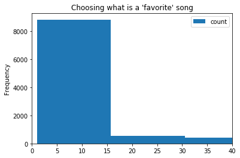

```python
ax = streaming.groupby(['artist','track']).size().to_frame('count').reset_index().plot(kind='hist',bins=9)
ax.set_xlim(0,40)
ax.set_title("Choosing what is a 'favorite' song")
```

### Occurences more than 15

```python
streaming.groupby(['artist','track']).size().to_frame('count').reset_index()
streaming = streaming.groupby(['artist','track']).size().to_frame('count').reset_index()
streaming = streaming[streaming['count']>=15]
df.head(5)
```

|  | artist | track | count |
| --- | --- | --- | --- |
| 42 | 5 Seconds of Summer | Youngblood | 20 |
| 50 | 6LACK | Ex Calling | 25 |
| 57 | 6LACK | Pretty Little Fears (feat. J. Cole) | 77 |
| 58 | 6LACK | Seasons (feat. Khalid) | 70 |
| 72 | 88rising | Head In The Clouds | 45 |

### Features dataset

```python
features = pd.read_csv("SpotifyFeatures.csv")

features = features.rename(columns={"artist_name":"artist","track_name":"track"})
features.head(5)
```

|  | genre | artist | track | track_id | popularity | acousticness | danceability | duration_ms | energy | instrumentalness | key | liveness | loudness | mode | speechiness | tempo | time_signature | valence |
| --- | --- | --- | --- | --- | --- | --- | --- | --- | --- | --- | --- | --- | --- | --- | --- | --- | --- | --- |
| 0 | Movie | Henri Salvador | C'est beau de faire un Show | 0BRjO6ga9RKCKjfDqeFgWV | 0 | 0.611 | 0.389 | 99373 | 0.910 | 0.000 | C# | 0.3460 | -1.828 | Major | 0.0525 | 166.969 | 4/4 | 0.814 |
| 1 | Movie | Martin & les fées | Perdu d'avance (par Gad Elmaleh) | 0BjC1NfoEOOusryehmNudP | 1 | 0.246 | 0.590 | 137373 | 0.737 | 0.000 | F# | 0.1510 | -5.559 | Minor | 0.0868 | 174.003 | 4/4 | 0.816 |
| 2 | Movie | Joseph Williams | Don't Let Me Be Lonely Tonight | 0CoSDzoNIKCRs124s9uTVy | 3 | 0.952 | 0.663 | 170267 | 0.131 | 0.000 | C | 0.1030 | -13.879 | Minor | 0.0362 | 99.488 | 5/4 | 0.368 |
| 3 | Movie | Henri Salvador | Dis-moi Monsieur Gordon Cooper | 0Gc6TVm52BwZD07Ki6tIvf | 0 | 0.703 | 0.240 | 152427 | 0.326 | 0.000 | C# | 0.0985 | -12.178 | Major | 0.0395 | 171.758 | 4/4 | 0.227 |
| 4 | Movie | Fabien Nataf | Ouverture | 0IuslXpMROHdEPvSl1fTQK | 4 | 0.950 | 0.331 | 82625 | 0.225 | 0.123 | F | 0.2020 | -21.150 | Major | 0.0456 | 140.576 | 4/4 | 0.390 |

The **favorite** column will be the variable that I will try to predict.

```python
features['same_artists'] = features.artist.isin(df.artist)
features['same_track'] = features.track.isin(df.track)
features["favorite"] = np.where((features["same_artists"] == True) & (features["same_track"] == True),1,0) # If both instances are True.
features = features.drop(["same_artists","same_track"],axis=1)
```

```python
future = features.copy(deep=True)
```

```python
features.genre.unique()
```

```
array(['Movie', 'R&B', 'A Capella', 'Alternative', 'Country', 'Dance',
       'Electronic', 'Anime', 'Folk', 'Blues', 'Opera', 'Hip-Hop',
       "Children's Music", 'Children’s Music', 'Rap', 'Indie',
       'Classical', 'Pop', 'Reggae', 'Reggaeton', 'Jazz', 'Rock', 'Ska',
       'Comedy', 'Soul', 'Soundtrack', 'World'], dtype=object)
```

```python
features
```

[output not shown]

Comedy stands out to the most as we want to know if 'songs' in this genre are actually songs.

```python
features[features.genre == 'Comedy'].describe()
```

|  | popularity | acousticness | danceability | duration_ms | energy | instrumentalness | liveness | loudness | speechiness | tempo | valence | favorite |
| --- | --- | --- | --- | --- | --- | --- | --- | --- | --- | --- | --- | --- |
| count | 9681.000000 | 9681.000000 | 9681.000000 | 9.681000e+03 | 9681.000000 | 9681.000000 | 9681.000000 | 9681.000000 | 9681.000000 | 9681.000000 | 9681.000000 | 9681.0 |
| mean | 21.342630 | 0.793098 | 0.559038 | 2.353052e+05 | 0.676094 | 0.000574 | 0.724775 | -11.689321 | 0.853532 | 98.235488 | 0.412764 | 0.0 |
| std | 8.428764 | 0.130313 | 0.089625 | 2.502539e+05 | 0.211705 | 0.009987 | 0.223437 | 4.777983 | 0.205918 | 27.839986 | 0.207258 | 0.0 |
| min | 0.000000 | 0.000363 | 0.239000 | 3.004000e+04 | 0.001410 | 0.000000 | 0.025800 | -31.047000 | 0.023000 | 32.451000 | 0.023700 | 0.0 |
| 25% | 15.000000 | 0.753000 | 0.499000 | 1.218800e+05 | 0.522000 | 0.000000 | 0.662000 | -14.649000 | 0.888000 | 79.720000 | 0.252000 | 0.0 |
| 50% | 20.000000 | 0.819000 | 0.561000 | 1.890570e+05 | 0.704000 | 0.000000 | 0.767000 | -11.209000 | 0.928000 | 90.124000 | 0.410000 | 0.0 |
| 75% | 26.000000 | 0.872000 | 0.620000 | 2.812930e+05 | 0.859000 | 0.000000 | 0.898000 | -8.088000 | 0.944000 | 115.128000 | 0.561000 | 0.0 |
| max | 61.000000 | 0.995000 | 0.898000 | 5.552917e+06 | 0.998000 | 0.352000 | 0.996000 | -0.255000 | 0.967000 | 207.157000 | 0.980000 | 0.0 |

We can look at the values in **instrumentalness**, **liveness**, and **speechiness** to deduce that there are almost no instrumentals, the recording is highly probable to be in front of a live audience, and that it contains a lot words. Therefore, we will be removing all songs from this genre because they do not accurately represent music and will distort the model with its **features**.

We can drop features **track_id** and **track** that have low correlation to our predictions.

```python
features = features[features.genre!='Comedy']

features = features.drop(columns='track_id')
```

```python
features = features.drop(columns='track')
```

```python
features.head(1)
```

|  | genre | artist | popularity | acousticness | danceability | duration_ms | energy | instrumentalness | key | liveness | loudness | mode | speechiness | tempo | time_signature | valence | favorite |
| --- | --- | --- | --- | --- | --- | --- | --- | --- | --- | --- | --- | --- | --- | --- | --- | --- | --- |
| 0 | Movie | Henri Salvador | 0 | 0.611 | 0.389 | 99373 | 0.91 | 0.0 | C# | 0.346 | -1.828 | Major | 0.0525 | 166.969 | 4/4 | 0.814 | 0 |

### Balancing Classes with Oversampling (SMOTE) and Feature Selection

Our model will predict most songs as the majority class (in our case, 0). Therefore, we will use SMOTE to oversample from the minority class to balance them out.

```python
features.favorite.value_counts()
```

```
0    219815
1      3229
Name: favorite, dtype: int64
```

```python
X = features.drop(columns=['favorite','genre','artist','key','mode','time_signature'])
y = features.favorite
oversample = SMOTE()
X, y = oversample.fit_resample(X, y)
X['favorite'] = y
X.head()
```

|  | popularity | acousticness | danceability | duration_ms | energy | instrumentalness | liveness | loudness | speechiness | tempo | valence | favorite |
| --- | --- | --- | --- | --- | --- | --- | --- | --- | --- | --- | --- | --- |
| 0 | 0 | 0.611 | 0.389 | 99373 | 0.910 | 0.000 | 0.3460 | -1.828 | 0.0525 | 166.969 | 0.814 | 0 |
| 1 | 1 | 0.246 | 0.590 | 137373 | 0.737 | 0.000 | 0.1510 | -5.559 | 0.0868 | 174.003 | 0.816 | 0 |
| 2 | 3 | 0.952 | 0.663 | 170267 | 0.131 | 0.000 | 0.1030 | -13.879 | 0.0362 | 99.488 | 0.368 | 0 |
| 3 | 0 | 0.703 | 0.240 | 152427 | 0.326 | 0.000 | 0.0985 | -12.178 | 0.0395 | 171.758 | 0.227 | 0 |
| 4 | 4 | 0.950 | 0.331 | 82625 | 0.225 | 0.123 | 0.2020 | -21.150 | 0.0456 | 140.576 | 0.390 | 0 |

### Correlation matrix

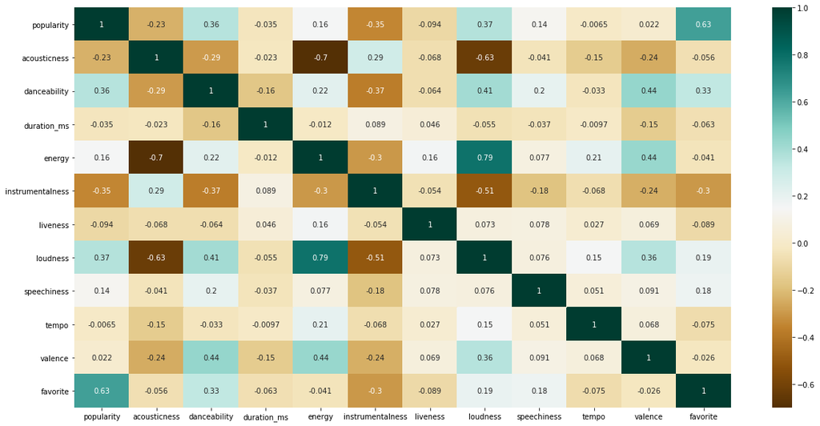

```python
plt.figure(figsize=(20,10))
c = X.corr()
corr = sns.heatmap(c,cmap="BrBG",annot=True)
```

**Popularity**, **danceability**, and **instrumentalness** have the highest associations, with **popularity** and **danceability** being positive and instrumentalness being negative.

## II) Recommander system

We will use 3 different methods:

- **Random Forest Classifier**
- **Decision Tree Classifier**
- **Logistic Regression**

```python
import sklearn
from sklearn.pipeline import Pipeline
from sklearn.model_selection import cross_val_score
from sklearn.model_selection import train_test_split
from sklearn.model_selection import GridSearchCV
from sklearn import metrics
from sklearn.metrics import f1_score

from sklearn.ensemble import RandomForestClassifier
from sklearn.linear_model import LogisticRegression
from sklearn.tree import DecisionTreeClassifier
```

### Split and train the data

```python
X_train, X_test, y_train, y_test = train_test_split(X.drop(columns='favorite'), X.favorite,test_size = .20)
```

We will use **cross-validation** to see how well each model generalizes and obtain a F1 score.

### Logistic Regression

```python
%%time

lr = LogisticRegression()
lr_scores = cross_val_score(lr, X_train, y_train, cv=10, scoring="f1")
np.mean(lr_scores)
```

```
CPU times: user 25.4 s, sys: 834 ms, total: 26.2 s
Wall time: 13.6 s
```

```
0.7911026485724648
```

### Decision Tree

```python
parameters = {
    'max_depth':[15,20,30],
}
dtc = Pipeline([('CV',GridSearchCV(DecisionTreeClassifier(), parameters, cv = 5))])
dtc.fit(X_train, y_train)
dtc.named_steps['CV'].best_params_
```

```
{'max_depth': 30}
```

```python
%%time

dt = DecisionTreeClassifier(max_depth=30)
dt_scores = cross_val_score(dt, X_train, y_train, cv=10, scoring="f1")
np.mean(dt_scores)
```

```
CPU times: user 1min 18s, sys: 1.49 s, total: 1min 19s
Wall time: 1min 42s
```

```
0.9778236467147376
```

### Random Forest

```python
parameters = {
    'max_depth':[6,12,15,20],
    'n_estimators':[20,30]
}
clf = Pipeline([('CV',GridSearchCV(RandomForestClassifier(), parameters, cv = 5))])
clf.fit(X_train, y_train)
clf.named_steps['CV'].best_params_
```

```
{'max_depth': 20, 'n_estimators': 30}
```

```python
%%time

rf = Pipeline([('rf', RandomForestClassifier(n_estimators = 20, max_depth = 30))])
rf_scores = cross_val_score(rf, X_train, y_train, cv=10, scoring="f1")
np.mean(rf_scores)
```

```
CPU times: user 4min 49s, sys: 3.71 s, total: 4min 52s
Wall time: 5min 15s
```

```
0.9914629343786274
```

Based on F1 score, we can conclude that the **Random Forest** is the best model for our prediction problem.

# III) Predictiions

```python
prediction = dt.predict(future.drop(columns=['track','track_id','favorite','genre','artist','key','time_signature','mode']))
```

```python
future['prediction'] = prediction
```

```python
# Gets only songs that were not favorites but are predicted to be
future = future[(future['favorite']==0) & (future['prediction'] == 1)]
```

```python
future = future.drop(columns=['track_id','energy','duration_ms','acousticness','key','liveness','loudness','mode','speechiness','tempo','time_signature','valence'])
```

```python
future
```

|  | genre | artist | track | popularity | danceability | instrumentalness | favorite | prediction |
| --- | --- | --- | --- | --- | --- | --- | --- | --- |
| 139 | R&B | Olivia O'Brien | Love Myself | 68 | 0.653 | 0.000000 | 0 | 1 |
| 140 | R&B | ELHAE | Needs | 61 | 0.510 | 0.000000 | 0 | 1 |
| 146 | R&B | Beyoncé | Flawless Remix | 69 | 0.639 | 0.000008 | 0 | 1 |
| 151 | R&B | Tierra Whack | CLONES | 61 | 0.791 | 0.018200 | 0 | 1 |
| 161 | R&B | Rihanna | Hate That I Love You | 72 | 0.637 | 0.000000 | 0 | 1 |
| ... | ... | ... | ... | ... | ... | ... | ... | ... |
| 231746 | Soul | Seal | Prayer For The Dying | 43 | 0.306 | 0.006050 | 0 | 1 |
| 232008 | Soul | 24hrs | Keys To My Ride (feat. PnB Rock) | 42 | 0.826 | 0.000000 | 0 | 1 |
| 232288 | Soul | Handsome Ghost | Here's To Endings | 42 | 0.504 | 0.006700 | 0 | 1 |
| 232407 | Soul | Seinabo Sey | Never Get Used To | 56 | 0.797 | 0.000001 | 0 | 1 |
| 232552 | Soul | Aftertheparty | Outrun | 38 | 0.761 | 0.004520 | 0 | 1 |

4589 rows × 8 columns